# HW5 - Annie Sherwood

**Dataset:** `day_missing.csv` - the UCI *Bike Sharing* daily data set (Capital Bikeshare, Washington D.C., 2011-2012) with some values removed and some outliers injected.

Each row is one day. Key columns (from the UCI data documentation):

| column | meaning |
| --- | --- |
| `dteday` | date |
| `season` | season code (mapping derived from the data below) |
| `weathersit` | 1 = Clear / few clouds, 2 = Mist / cloudy, 3 = Light rain or snow, 4 = Heavy rain / snow / fog |
| `temp`, `atemp` | normalized temperature and "feels-like" temperature |
| `hum`, `windspeed` | normalized humidity and wind speed |
| `casual`, `registered`, `cnt` | casual riders, registered riders, total riders |
| `workingday` | 1 = neither weekend nor holiday, else 0 |

The notebook is meant to be run top-to-bottom; each question builds on the DataFrame produced by the previous one.

## Setup - imports and shared constants

```python
from pathlib import Path

import matplotlib.pyplot as plt
import numpy as np
import pandas as pd
import seaborn as sns

DATA_FILE = 'day_missing.csv'

# Fixed categorical colour order (blue, orange, aqua, yellow) so that a
# category always keeps the same colour across every chart.
PALETTE = ['#2a78d6', '#eb6834', '#1baf7a', '#eda100']

# Weather-situation names from the UCI Bike Sharing documentation.
WEATHER_NAMES = {
    1: 'Clear',
    2: 'Mist',
    3: 'Light Rain or Snow',
    4: 'Heavy Rain or Snow',
}

sns.set_theme(style='whitegrid')
```

## Data inspection

Required first output, in order: shape, dtypes, missing values per column, the sorted unique values of `season` and `weathersit`, and the evidence for the season mapping.

```python
if not Path(DATA_FILE).exists():
    raise FileNotFoundError(
        f'{DATA_FILE} was not found in {Path.cwd()}. Put the CSV in the '
        'same folder as this notebook, then restart and run all cells.'
    )
df = pd.read_csv(DATA_FILE)

# 1. Shape
print('Shape:', df.shape)

# 2. Data types
print('\nData types:')
print(df.dtypes)

# 3. Missing values per column
print('\nMissing values per column:')
print(df.isna().sum())

# 4. Sorted unique values of the two coded columns
print('\nUnique season values:    ', sorted(df['season'].unique().tolist()))
print('Unique weathersit values:', sorted(df['weathersit'].unique().tolist()))

# 5. Evidence for the season mapping: which months fall in each code ...
print('\nDays per (month, season code):')
print(pd.crosstab(df['mnth'], df['season']))

# ... and the calendar dates on which each code starts and ends.
dates = pd.to_datetime(df['dteday'], format='%m/%d/%Y')
day_of_year = dates.dt.strftime('%m-%d')
print('\nMonth-day range covered by each season code:')
print(day_of_year.groupby(df['season']).agg(['min', 'max']))

# Codes 1-3 never wrap the year, so min/max show their exact boundaries.
# Code 1 covers January, so its December days are the ones after the
# season-4 days end.
for code_value in sorted(df['season'].unique()):
    in_season = dates[df['season'] == code_value]
    runs = in_season.diff().dt.days.ne(1).cumsum()
    first_run = in_season.groupby(runs).agg(['min', 'max']).iloc[0]
    print(f'season {code_value}: first run '
          f'{first_run["min"]:%Y-%m-%d} to {first_run["max"]:%Y-%m-%d}')
```

```
Shape: (731, 16)

Data types:
instant         int64
dteday            str
season          int64
yr              int64
mnth            int64
holiday         int64
weekday         int64
workingday      int64
weathersit      int64
temp          float64
atemp         float64
hum           float64
windspeed     float64
casual        float64
registered    float64
cnt           float64
dtype: object

Missing values per column:
instant        0
dteday         0
season         0
yr             0
mnth           0
holiday        0
weekday        0
workingday     0
weathersit     0
temp          18
atemp         21
hum            8
windspeed     21
casual        12
registered    14
cnt           17
dtype: int64

```

[output cut: 15 more lines]

```
10       0   0   0  62
11       0   0   0  60
12      22   0   0  40

Month-day range covered by each season code:
          min    max
season
1       01-01  12-31
2       03-21  06-20
3       06-21  09-22
4       09-23  12-20
season 1: first run 2011-01-01 to 2011-03-20
season 2: first run 2011-03-21 to 2011-06-20
season 3: first run 2011-06-21 to 2011-09-22
season 4: first run 2011-09-23 to 2011-12-20
```

**Reading the evidence.** Code 1 holds all of January and February, the first ~20 days of March and the last ~10 days of December. Code 2 starts around 21 March and runs to around 20 June; code 3 runs from about 21 June to about 22 September; code 4 from about 23 September to about 20 December. Those boundaries are the astronomical equinoxes and solstices, so:

- 1 = **Winter** (21 Dec - 20 Mar)
- 2 = **Spring** (21 Mar - 20 Jun)
- 3 = **Summer** (21 Jun - 22 Sep)
- 4 = **Fall** (23 Sep - 20 Dec)

The mapping below is built from the data: each code is labelled by the month it covers most often, and that month is translated to its astronomical season.

```python
# Month that falls inside each season code most often.
dominant_month = pd.crosstab(df['season'], df['mnth']).idxmax(axis=1)

# Northern-hemisphere astronomical season each whole month belongs to.
MONTH_TO_SEASON = {
    1: 'Winter', 2: 'Winter', 3: 'Spring', 4: 'Spring', 5: 'Spring',
    6: 'Summer', 7: 'Summer', 8: 'Summer', 9: 'Fall', 10: 'Fall',
    11: 'Fall', 12: 'Winter',
}

SEASON_NAMES = {
    int(code_value): MONTH_TO_SEASON[month]
    for code_value, month in dominant_month.items()
}
print('Dominant month per season code:', dominant_month.to_dict())
print('Season mapping:', SEASON_NAMES)

WEATHER_PRESENT = {
    int(code_value): WEATHER_NAMES[code_value]
    for code_value in sorted(df['weathersit'].unique())
}
print('Weather mapping (codes present in the data):', WEATHER_PRESENT)
```

```
Dominant month per season code: {1: 1, 2: 5, 3: 7, 4: 10}
Season mapping: {1: 'Winter', 2: 'Spring', 3: 'Summer', 4: 'Fall'}
Weather mapping (codes present in the data): {1: 'Clear', 2: 'Mist', 3: 'Light Rain or Snow'}
```

Note that `weathersit` only takes the values 1, 2 and 3 - there are no *Heavy Rain or Snow* (code 4) days in this data, so charts that use `weathersit` show three categories.

## Q1. Four-moment table

A column qualifies when it is numeric **and** has more than 8 distinct non-missing values. Applied strictly, this selects `instant` (a row counter) and `mnth` (12 values) as well as the measured variables; they are kept because the rule says so, although they are not meaningful continuous measurements.

Kurtosis is Fisher's (excess) kurtosis - a normal distribution scores 0. pandas' `.kurt()` uses that definition and skips missing values.

```python
numeric_cols = df.select_dtypes(include='number').columns
continuous_cols = [col for col in numeric_cols if df[col].nunique() > 8]
print('Columns with more than 8 distinct values:', continuous_cols)

moments = pd.DataFrame({
    'mean': df[continuous_cols].mean(),
    'std': df[continuous_cols].std(),
    'skew': df[continuous_cols].skew(),
    'kurtosis': df[continuous_cols].kurt(),
}).round(4)
moments
```

```
Columns with more than 8 distinct values: ['instant', 'mnth', 'temp', 'atemp', 'hum', 'windspeed', 'casual', 'registered', 'cnt']
```

|  | mean | std | skew | kurtosis |
| --- | --- | --- | --- | --- |
| instant | 366.0000 | 211.1658 | 0.0000 | -1.2000 |
| mnth | 6.5198 | 3.4519 | -0.0081 | -1.2091 |
| temp | 0.8209 | 3.7898 | 12.5146 | 162.4505 |
| atemp | 0.4747 | 0.1637 | -0.1356 | -0.9854 |
| hum | 0.6282 | 0.1425 | -0.0772 | -0.0491 |
| windspeed | 0.1909 | 0.0777 | 0.6692 | 0.4034 |
| casual | 846.4312 | 687.1555 | 1.2700 | 1.3391 |
| registered | 3654.6402 | 1557.7495 | 0.0422 | -0.7027 |
| cnt | 4474.5224 | 1931.4106 | -0.0329 | -0.8005 |

## Q2. Kurtosis flag for possible outliers (|kurtosis| > 1.8)

```python
KURTOSIS_LIMIT = 1.8

flagged = moments.loc[moments['kurtosis'].abs() > KURTOSIS_LIMIT, 'kurtosis']
if flagged.empty:
    print(f'No variable has |kurtosis| > {KURTOSIS_LIMIT}.')
else:
    print(f'Variables with |kurtosis| > {KURTOSIS_LIMIT}:',
          flagged.index.tolist())
    print(flagged.to_string())
```

```
Variables with |kurtosis| > 1.8: ['temp']
temp    162.4505
```

The flagged variables have tails heavier than the threshold allows, which suggests outliers. `temp` is the clearest case: its maximum is far outside the 0-1 normalized range the rest of the column uses.

## Q3. Outliers set to missing (2.1 x IQR rule)

For each Q1 column: Q1 and Q3 are the 25th and 75th percentiles, IQR = Q3 - Q1, and a value is an outlier if it is below Q1 - 2.1 x IQR or above Q3 + 2.1 x IQR. The fences are computed by hand from the quantiles; outliers are replaced with `np.nan`.

```python
IQR_MULTIPLIER = 2.1

outlier_counts = {}
for col in continuous_cols:
    q1 = df[col].quantile(0.25)
    q3 = df[col].quantile(0.75)
    iqr = q3 - q1
    lower_fence = q1 - IQR_MULTIPLIER * iqr
    upper_fence = q3 + IQR_MULTIPLIER * iqr

    # Comparisons with NaN are False, so existing gaps are not counted.
    is_outlier = (df[col] < lower_fence) | (df[col] > upper_fence)
    outlier_counts[col] = int(is_outlier.sum())
    if is_outlier.any():
        df.loc[is_outlier, col] = np.nan

outlier_table = (
    pd.Series(outlier_counts, name='outliers_replaced')
    .rename_axis('variable')
    .loc[lambda counts: counts > 0]
    .to_frame()
)
outlier_table
```

| variable | outliers_replaced |
| --- | --- |
| temp | 6 |
| hum | 1 |
| windspeed | 1 |
| casual | 14 |

## Q4. Mean imputation (only the columns changed in Q3)

Only the columns listed in the Q3 table are imputed, each with the mean of its remaining values (the post-Q3 mean). Other columns keep their original missing values.

```python
treated_cols = outlier_table.index.tolist()

post_q3_means = df[treated_cols].mean()
df[treated_cols] = df[treated_cols].fillna(post_q3_means)

print('Imputed columns and the mean used:')
print(post_q3_means.round(4).to_string())
print('\nMissing values remaining in imputed columns:')
print(df[treated_cols].isna().sum().to_string())
assert df[treated_cols].isna().sum().sum() == 0

print('\nMissing values remaining in all columns (untreated columns '
      'keep theirs):')
print(df.isna().sum().to_string())
```

```
Imputed columns and the mean used:
temp           0.4973
hum            0.6291
windspeed      0.1904
casual       803.3206

Missing values remaining in imputed columns:
temp         0
hum          0
windspeed    0
casual       0

Missing values remaining in all columns (untreated columns keep theirs):
instant        0
dteday         0
season         0
yr             0
mnth           0
holiday        0
weekday        0
workingday     0
weathersit     0
temp           0
atemp         21
hum            0
windspeed      0
casual         0
registered    14
cnt           17
```

## Q5. Post-imputation kurtosis check

```python
kurtosis_check = pd.DataFrame({
    'kurtosis_before': moments.loc[treated_cols, 'kurtosis'],
    'kurtosis_after': df[treated_cols].kurt().round(4),
})
kurtosis_check['difference'] = (
    kurtosis_check['kurtosis_after'] - kurtosis_check['kurtosis_before']
).round(4)
kurtosis_check = kurtosis_check.sort_values(
    'difference', key=np.abs, ascending=False
)
kurtosis_check
```

|  | kurtosis_before | kurtosis_after | difference |
| --- | --- | --- | --- |
| temp | 162.4505 | -1.0611 | -163.5116 |
| casual | 1.3391 | 0.9124 | -0.4267 |
| hum | -0.0491 | -0.4127 | -0.3636 |
| windspeed | 0.4034 | 0.2662 | -0.1372 |

```python
biggest = kurtosis_check.index[0]
change = kurtosis_check.loc[biggest, 'difference']
direction = 'lighter' if change < 0 else 'heavier'
print(f'Largest change: {biggest} ({change:+.4f}); tails became {direction}.')

still_high = df[continuous_cols].kurt()
still_high = still_high[still_high.abs() > KURTOSIS_LIMIT].round(4)
if still_high.empty:
    print(f'After treatment, no column has |kurtosis| > {KURTOSIS_LIMIT}.')
else:
    print(f'Columns still above |kurtosis| > {KURTOSIS_LIMIT}:')
    print(still_high.to_string())
```

```
Largest change: temp (-163.5116); tails became lighter.
After treatment, no column has |kurtosis| > 1.8.
```

**Interpretation.** `temp` changed the most. Its kurtosis fell from a very large positive value (162.45) (a handful of impossible readings such as 58.75 on a 0-1 scale) to a negative value (-1.06), so its tails became much **lighter** - after the extreme values were replaced with the mean, the distribution is flatter than a normal one, which is what a seasonal temperature series looks like. The other treated columns moved by much smaller amounts, also toward lighter tails. The printout above shows whether any column still exceeds the 1.8 threshold after treatment.

## Q6. `dteday` as a DatetimeIndex

```python
df['dteday'] = pd.to_datetime(df['dteday'], format='%m/%d/%Y')
df = df.set_index('dteday')

# set_index already removes the column; guard in case it was re-added.
df = df.drop(columns='dteday', errors='ignore')

assert isinstance(df.index, pd.DatetimeIndex)
df.info()
```

```
<class 'pandas.DataFrame'>
DatetimeIndex: 731 entries, 2011-01-01 to 2012-12-31
Data columns (total 15 columns):
 #   Column      Non-Null Count  Dtype
---  ------      --------------  -----
 0   instant     731 non-null    int64
 1   season      731 non-null    int64
 2   yr          731 non-null    int64
 3   mnth        731 non-null    int64
 4   holiday     731 non-null    int64
 5   weekday     731 non-null    int64
 6   workingday  731 non-null    int64
 7   weathersit  731 non-null    int64
 8   temp        731 non-null    float64
 9   atemp       710 non-null    float64
 10  hum         731 non-null    float64
 11  windspeed   731 non-null    float64
 12  casual      731 non-null    float64
 13  registered  717 non-null    float64
 14  cnt         714 non-null    float64
dtypes: float64(7), int64(8)
memory usage: 91.4 KB
```

## Q7. Scatter-plot matrix coloured by weather situation

The numeric `weathersit` codes are replaced by the documented names so the legend reads *Clear / Mist / Light Rain or Snow*. (The horizontal band of points at `temp` = 0.497 is the Q4 mean imputation.)

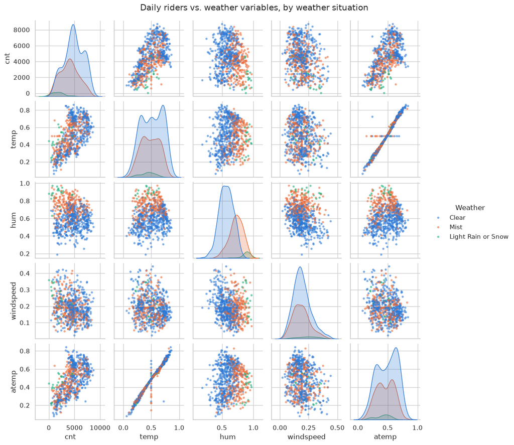

```python
matrix_vars = ['cnt', 'temp', 'hum', 'windspeed', 'atemp']
weather_order = list(WEATHER_PRESENT.values())

plot_df = df[matrix_vars].copy()
plot_df['Weather'] = pd.Categorical(
    df['weathersit'].map(WEATHER_PRESENT), categories=weather_order
)

grid = sns.pairplot(
    plot_df,
    vars=matrix_vars,
    hue='Weather',
    hue_order=weather_order,
    palette=PALETTE[:len(weather_order)],
    plot_kws={'s': 14, 'alpha': 0.6, 'edgecolor': 'none'},
    diag_kind='kde',
    height=2.1,
)
grid.figure.suptitle(
    'Daily riders vs. weather variables, by weather situation', y=1.02
)
plt.show()
```

## Q8. Boxplots of `cnt` by season

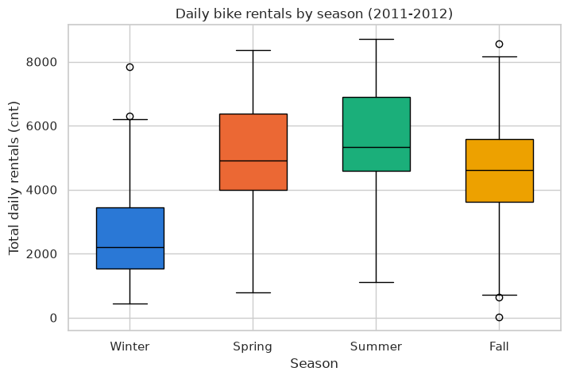

```python
season_order = [SEASON_NAMES[key] for key in sorted(SEASON_NAMES)]

# One array of daily counts per season, in chronological (code) order.
season_groups = [
    df.loc[df['season'] == key, 'cnt'].dropna().to_numpy()
    for key in sorted(SEASON_NAMES)
]

fig, ax = plt.subplots(figsize=(8, 5))
boxes = ax.boxplot(season_groups, patch_artist=True, widths=0.55)
for box, colour in zip(boxes['boxes'], PALETTE):
    box.set_facecolor(colour)
for median in boxes['medians']:
    median.set_color('black')
ax.set_xticks(range(1, len(season_order) + 1))
ax.set_xticklabels(season_order)
ax.set_title('Daily bike rentals by season (2011-2012)')
ax.set_xlabel('Season')
ax.set_ylabel('Total daily rentals (cnt)')
plt.show()
```

## Q9. Casual vs. registered riders with marginal histograms

`seaborn.JointGrid` draws the scatter plot in the centre and a histogram of each variable in the margins; both are split by `workingday`.

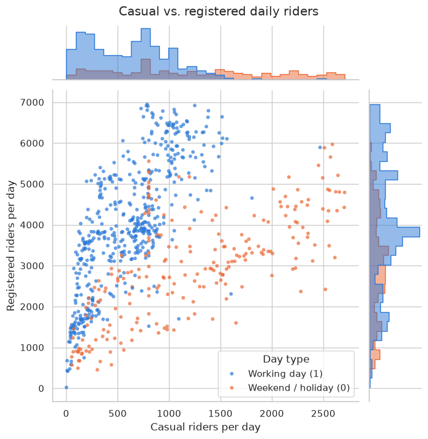

```python
joint_df = df[['casual', 'registered']].copy()
joint_df['Day type'] = df['workingday'].map(
    {0: 'Weekend / holiday (0)', 1: 'Working day (1)'}
)
day_order = ['Working day (1)', 'Weekend / holiday (0)']

joint = sns.JointGrid(
    data=joint_df,
    x='casual',
    y='registered',
    hue='Day type',
    hue_order=day_order,
    palette=PALETTE[:2],
    height=7,
)
joint.plot_joint(sns.scatterplot, s=18, alpha=0.7, edgecolor='none')
joint.plot_marginals(sns.histplot, bins=30, alpha=0.5, element='step')
joint.set_axis_labels('Casual riders per day', 'Registered riders per day')
joint.ax_joint.legend(title='Day type', loc='lower right')
joint.figure.suptitle('Casual vs. registered daily riders', y=1.02)
plt.show()
```

Working days are dominated by registered (commuter) riders, while weekends and holidays attract many more casual riders for a similar number of registered riders.

## Q10. Treemap of total riders by weather situation

One rectangle per `weathersit` value present in the data, sized by the sum of `cnt`, labelled with the weather name and its total, each in its own colour.

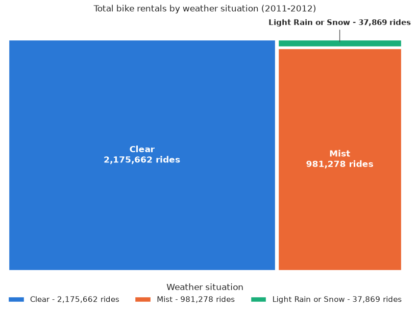

```python
weather_totals = df.groupby('weathersit')['cnt'].sum().sort_values(
    ascending=False
)
labels = [
    f'{WEATHER_PRESENT[code_value]}\n{total:,.0f} rides'
    for code_value, total in weather_totals.items()
]
colours = [PALETTE[code_value - 1] for code_value in weather_totals.index]



def treemap_layout(sizes, x, y, width, height, gap=0.8):
    """Return one (x, y, w, h) rectangle per size, areas proportional.

    Each rectangle takes its share off the longer side of the space left
    over, then the rest is laid out the same way (slice-and-dice).
    """
    rects = []
    remaining = float(sum(sizes))
    for size in sizes:
        share = size / remaining
        if width >= height:
            w = width * share
            rects.append((x, y, w, height))
            x, width = x + w, width - w
        else:
            h = height * share
            rects.append((x, y, width, h))
            y, height = y + h, height - h
        remaining -= size
    # Shrink each rectangle slightly so neighbours are separated by a gap.
    return [(rx + gap / 2, ry + gap / 2, rw - gap, rh - gap)
            for rx, ry, rw, rh in rects]


CANVAS = 100
rects = treemap_layout(list(weather_totals.values), 0, 0, CANVAS, CANVAS)

fig, ax = plt.subplots(figsize=(10, 6.5))
for (rx, ry, rw, rh), label, colour in zip(rects, labels, colours):
    ax.add_patch(plt.Rectangle(
        (rx, ry), rw, rh,
        facecolor=colour, label=label.replace('\n', ' - '),
    ))
    centre_x = rx + rw / 2
    centre_y = ry + rh / 2
    if min(rw, rh) > 10:
        ax.text(centre_x, centre_y, label, ha='center', va='center',
                color='white', fontsize=12, weight='bold')
    else:
        # Too thin to hold text: label it just outside with a pointer.
        ax.annotate(label.replace('\n', ' - '), xy=(centre_x, centre_y),
                    xytext=(centre_x, CANVAS + 6), ha='center',
                    fontsize=11, weight='bold',
                    arrowprops={'arrowstyle': '-', 'color': '0.3'})

ax.set_xlim(0, CANVAS)
ax.set_ylim(0, CANVAS + 10)
ax.legend(loc='upper center', bbox_to_anchor=(0.5, -0.02), ncol=3,
          frameon=False, title='Weather situation')
ax.set_title('Total bike rentals by weather situation (2011-2012)')
ax.axis('off')
plt.show()
```

Clear days account for most rides, misty days for most of the rest, and light rain or snow for only a small share; heavy rain or snow never occurs in this data set, so it has no rectangle.